# Stacks

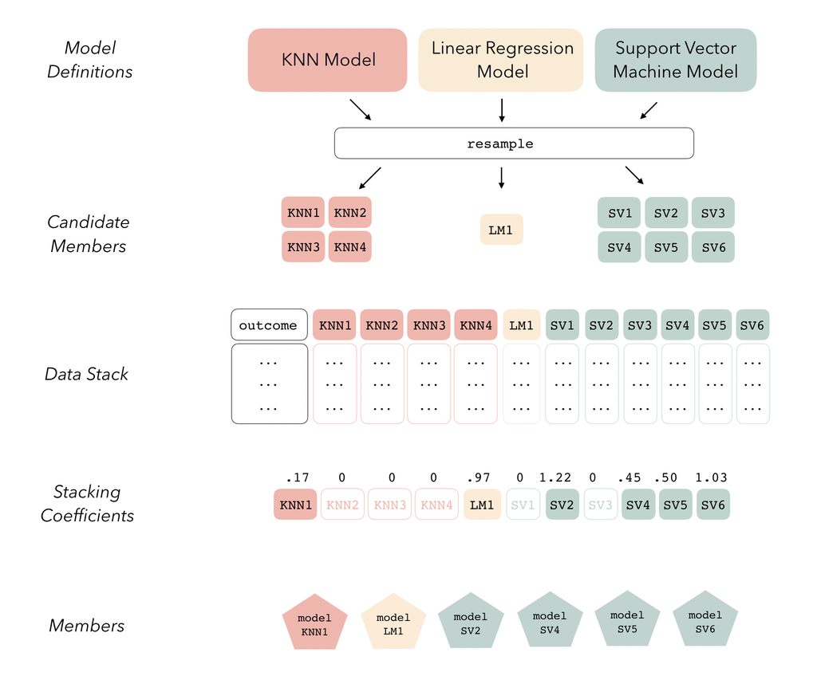

# Preparation

## Data

```r
data("tree_frogs")

# subset the data
tree_frogs <- tree_frogs %>%
  filter(!is.na(latency)) %>%
  select(-c(clutch, hatched))
```

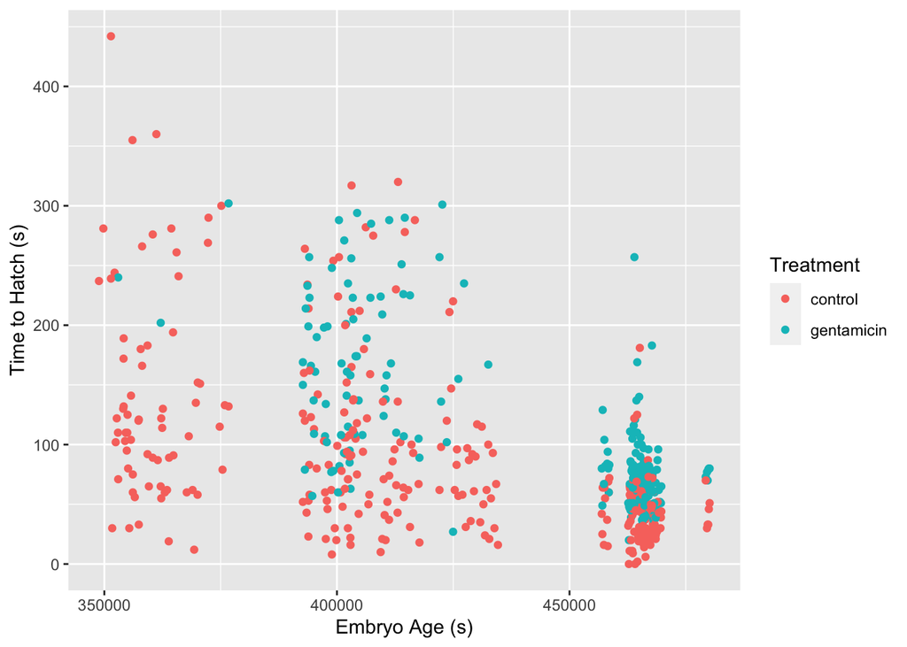

```r
library(ggplot2)

ggplot(tree_frogs) +
  aes(x = age, y = latency, color = treatment) +
  geom_point() +
  labs(x = "Embryo Age (s)", y = "Time to Hatch (s)", col = "Treatment")
```

## Recipe

```r
# some setup: resampling and a basic recipe
set.seed(1)
tree_frogs_split <- initial_split(tree_frogs)
tree_frogs_train <- training(tree_frogs_split)
tree_frogs_test  <- testing(tree_frogs_split)

set.seed(1)
folds <- rsample::vfold_cv(tree_frogs_train, v = 5)

tree_frogs_rec <-
  recipe(latency ~ ., data = tree_frogs_train)

metric <- metric_set(rmse)
```

## Prepare Stack

```r
ctrl_grid <- control_stack_grid()
ctrl_res <- control_stack_resamples()
```

# Models

## KNN

```r
# create a model definition
knn_spec <-
  nearest_neighbor(
    mode = "regression",
    neighbors = tune("k")
  ) %>%
  set_engine("kknn")

knn_spec
```

```
## K-Nearest Neighbor Model Specification (regression)
##
## Main Arguments:
##   neighbors = tune("k")
##
## Computational engine: kknn
```

```r
# extend the recipe
knn_rec <-
  tree_frogs_rec %>%
  step_dummy(all_nominal()) %>%
  step_zv(all_predictors(), skip = TRUE) %>%
  step_impute_mean(all_numeric(), skip = TRUE) %>%
  step_normalize(all_numeric(), skip = TRUE)
```

```r
# add both to a workflow
knn_wflow <-
  workflow() %>%
  add_model(knn_spec) %>%
  add_recipe(knn_rec)

knn_wflow
```

```
## ══ Workflow ════════════════════════════════════════════════════════════════════
## Preprocessor: Recipe
## Model: nearest_neighbor()
##
## ── Preprocessor ────────────────────────────────────────────────────────────────
## 4 Recipe Steps
##
## • step_dummy()
## • step_zv()
## • step_impute_mean()
## • step_normalize()
##
## ── Model ───────────────────────────────────────────────────────────────────────
## K-Nearest Neighbor Model Specification (regression)
##
## Main Arguments:
##   neighbors = tune("k")
##
## Computational engine: kknn
```

```r
# tune k and fit to the 5-fold cv
set.seed(2020)
knn_res <-
  tune_grid(
    knn_wflow,
    resamples = folds,
    metrics = metric,
    grid = 4,
    control = ctrl_grid
  )

knn_res
```

```
## # Tuning results
## # 5-fold cross-validation
## # A tibble: 5 × 5
##   splits           id    .metrics         .notes           .predictions
##   <list>           <chr> <list>           <list>           <list>
## 1 <split [343/86]> Fold1 <tibble [4 × 5]> <tibble [0 × 1]> <tibble [344 × 5]>
## 2 <split [343/86]> Fold2 <tibble [4 × 5]> <tibble [0 × 1]> <tibble [344 × 5]>
## 3 <split [343/86]> Fold3 <tibble [4 × 5]> <tibble [0 × 1]> <tibble [344 × 5]>
## 4 <split [343/86]> Fold4 <tibble [4 × 5]> <tibble [0 × 1]> <tibble [344 × 5]>
## 5 <split [344/85]> Fold5 <tibble [4 × 5]> <tibble [0 × 1]> <tibble [340 × 5]>
```

## Linear Regression

```r
# create a model definition
lin_reg_spec <-
  linear_reg() %>%
  set_engine("lm")

# extend the recipe
lin_reg_rec <-
  tree_frogs_rec %>%
  step_dummy(all_nominal()) %>%
  step_zv(all_predictors(), skip = TRUE)

# add both to a workflow
lin_reg_wflow <-
  workflow() %>%
  add_model(lin_reg_spec) %>%
  add_recipe(lin_reg_rec)

# fit to the 5-fold cv
set.seed(2020)
lin_reg_res <-
  fit_resamples(
    lin_reg_wflow,
    resamples = folds,
    metrics = metric,
    control = ctrl_res
  )

lin_reg_res
```

```
## # Resampling results
## # 5-fold cross-validation
## # A tibble: 5 × 5
##   splits           id    .metrics         .notes           .predictions
##   <list>           <chr> <list>           <list>           <list>
## 1 <split [343/86]> Fold1 <tibble [1 × 4]> <tibble [0 × 1]> <tibble [86 × 4]>
## 2 <split [343/86]> Fold2 <tibble [1 × 4]> <tibble [0 × 1]> <tibble [86 × 4]>
## 3 <split [343/86]> Fold3 <tibble [1 × 4]> <tibble [0 × 1]> <tibble [86 × 4]>
## 4 <split [343/86]> Fold4 <tibble [1 × 4]> <tibble [0 × 1]> <tibble [86 × 4]>
## 5 <split [344/85]> Fold5 <tibble [1 × 4]> <tibble [0 × 1]> <tibble [85 × 4]>
```

## SVM

```r
# create a model definition
svm_spec <-
  svm_rbf(
    cost = tune("cost"),
    rbf_sigma = tune("sigma")
  ) %>%
  set_engine("kernlab") %>%
  set_mode("regression")

# extend the recipe
svm_rec <-
  tree_frogs_rec %>%
  step_dummy(all_nominal()) %>%
  step_zv(all_predictors(), skip = TRUE) %>%
  step_meanimpute(all_numeric(), skip = TRUE) %>%
  step_corr(all_predictors(), skip = TRUE) %>%
  step_normalize(all_numeric(), skip = TRUE)
# add both to a workflow
svm_wflow <-
  workflow() %>%
  add_model(svm_spec) %>%
  add_recipe(svm_rec)

# tune cost and sigma and fit to the 5-fold cv
set.seed(2020)
svm_res <-
  tune_grid(
    svm_wflow,
    resamples = folds,
    grid = 6,
    metrics = metric,
    control = ctrl_grid
  )

svm_res
```

```
## # Tuning results
## # 5-fold cross-validation
## # A tibble: 5 × 5
##   splits           id    .metrics         .notes           .predictions
##   <list>           <chr> <list>           <list>           <list>
## 1 <split [343/86]> Fold1 <tibble [6 × 6]> <tibble [0 × 1]> <tibble [516 × 6]>
## 2 <split [343/86]> Fold2 <tibble [6 × 6]> <tibble [0 × 1]> <tibble [516 × 6]>
## 3 <split [343/86]> Fold3 <tibble [6 × 6]> <tibble [0 × 1]> <tibble [516 × 6]>
## 4 <split [343/86]> Fold4 <tibble [6 × 6]> <tibble [0 × 1]> <tibble [516 × 6]>
## 5 <split [344/85]> Fold5 <tibble [6 × 6]> <tibble [0 × 1]> <tibble [510 × 6]>
```

# Stacking

The `stacks()` function works sort of like the ggplot() constructor from ggplot2—the function creates a basic structure that the object will be built on top of—except you’ll pipe the outputs rather than adding them with +.

The `add_candidates()` function adds ensemble members to the stack.

```r
tree_frogs_data_st <-
  stacks() %>%
  add_candidates(knn_res) %>%
  add_candidates(lin_reg_res) %>%
  add_candidates(svm_res)
```

```r
as_tibble(tree_frogs_data_st)
```

```
## # A tibble: 429 × 12
##    latency knn_res_1_1 knn_res_1_2 knn_res_1_3 knn_res_1_4 lin_reg_res_1_1
##      <dbl>       <dbl>       <dbl>       <dbl>       <dbl>           <dbl>
##  1     142      -0.496      -0.478      -0.492      -0.494           114.
##  2      79      -0.381      -0.446      -0.542      -0.553            78.6
##  3      50      -0.311      -0.352      -0.431      -0.438            81.5
##  4      68      -0.312      -0.368      -0.463      -0.473            78.6
##  5      64      -0.496      -0.478      -0.492      -0.494            36.5
##  6      52      -0.391      -0.412      -0.473      -0.482           124.
##  7      39      -0.523      -0.549      -0.581      -0.587            35.2
##  8      46      -0.523      -0.549      -0.581      -0.587            37.1
##  9     137      -0.287      -0.352      -0.447      -0.456            78.8
## 10      73      -0.523      -0.549      -0.581      -0.587            38.8
## # … with 419 more rows, and 6 more variables: svm_res_1_1 <dbl>,
## #   svm_res_1_4 <dbl>, svm_res_1_3 <dbl>, svm_res_1_5 <dbl>, svm_res_1_2 <dbl>,
## #   svm_res_1_6 <dbl>
```

The first column gives the first response value, and the remaining columns give the assessment set predictions for each ensemble member. Since we’re in the regression case, there’s only one column per ensemble member. In classification settings, there are as many columns as there are levels of the outcome variable per candidate ensemble member.

# Fit the Stack

The outputs from each of these candidate ensemble members are highly correlated, so the blend_predictions() function performs regularization to figure out how we can combine the outputs from the stack members to come up with a final prediction.

```r
tree_frogs_model_st <-
  tree_frogs_data_st %>%
  blend_predictions()
```

```r
tree_frogs_model_st
```

```
## ── A stacked ensemble model ─────────────────────────────────────
```

```
##
## Out of 11 possible candidate members, the ensemble retained 4.
## Penalty: 0.1.
## Mixture: 1.
```

```
##
## The 4 highest weighted members are:
```

```
## # A tibble: 4 × 3
##   member          type              weight
##   <chr>           <chr>              <dbl>
## 1 svm_res_1_6     svm_rbf          352.
## 2 knn_res_1_4     nearest_neighbor  76.8
## 3 svm_res_1_2     svm_rbf           27.1
## 4 lin_reg_res_1_1 linear_reg         0.924
```

```
##
## Members have not yet been fitted with `fit_members()`.
```

The blend_predictions function determines how member model output will ultimately be combined in the final prediction by fitting a LASSO model on the data stack, predicting the true assessment set outcome using the predictions from each of the candidate members. Candidates with nonzero stacking coefficients become members.

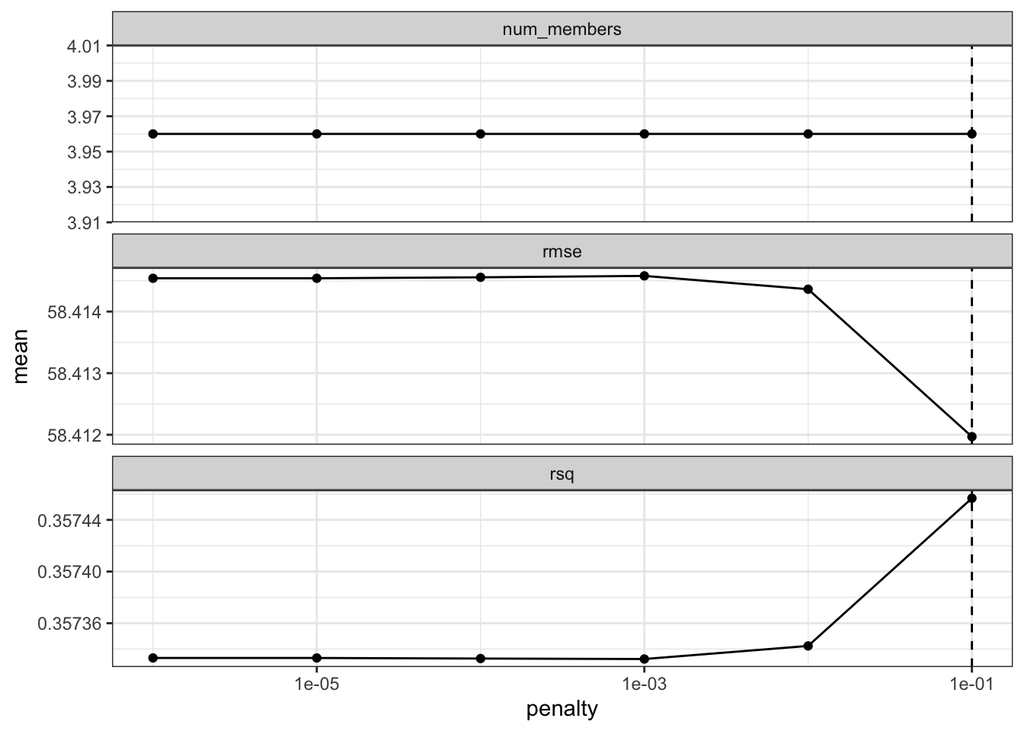

```r
theme_set(theme_bw())
autoplot(tree_frogs_model_st)
```

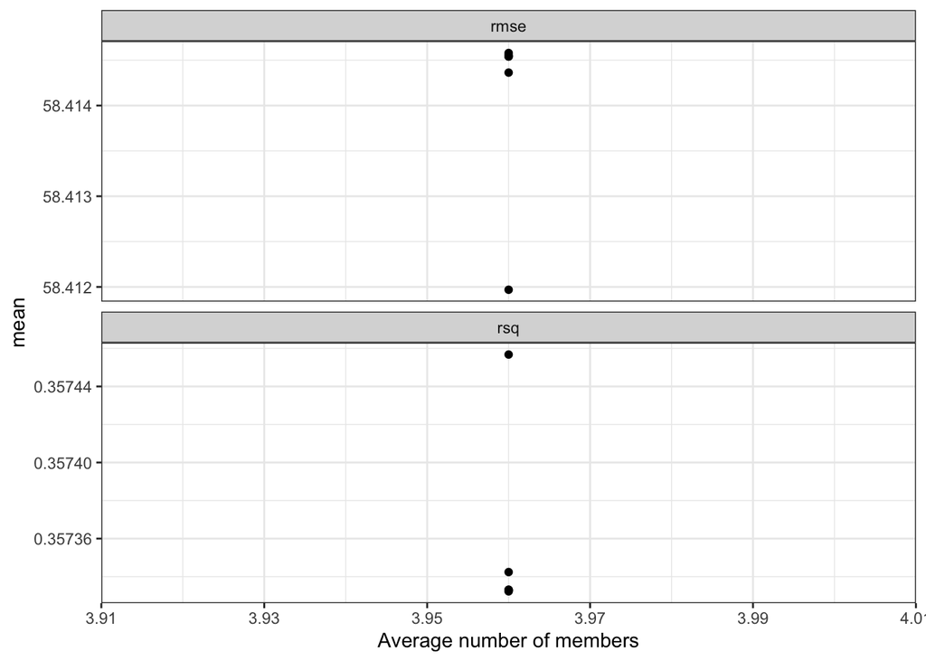

```r
autoplot(tree_frogs_model_st, type = "members")
```

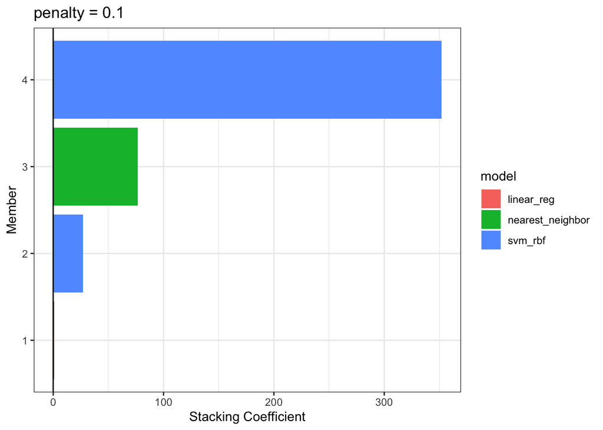

```r
autoplot(tree_frogs_model_st, type = "weights")
```

Now that we know how to combine our model output, we can fit the candidates with non-zero stacking coefficients on the full training set.

```r
tree_frogs_model_st <-
  tree_frogs_model_st %>%
  fit_members()
```

To identify which model configurations were assigned what stacking coefficients, we can make use of the collect_parameters() function:

```r
collect_parameters(tree_frogs_model_st, "svm_res")
```

```
## # A tibble: 6 × 4
##   member         cost    sigma  coef
##   <chr>         <dbl>    <dbl> <dbl>
## 1 svm_res_1_1 0.00143 6.64e- 9   0
## 2 svm_res_1_2 3.59    3.95e- 4  27.1
## 3 svm_res_1_3 0.0978  1.81e- 2   0
## 4 svm_res_1_4 0.00849 2.16e-10   0
## 5 svm_res_1_5 0.256   4.54e- 1   0
## 6 svm_res_1_6 7.64    3.16e- 7 352.
```

This object is now ready to predict with new data!

```r
tree_frogs_test <-
  tree_frogs_test %>%
  bind_cols(predict(tree_frogs_model_st, .))
```

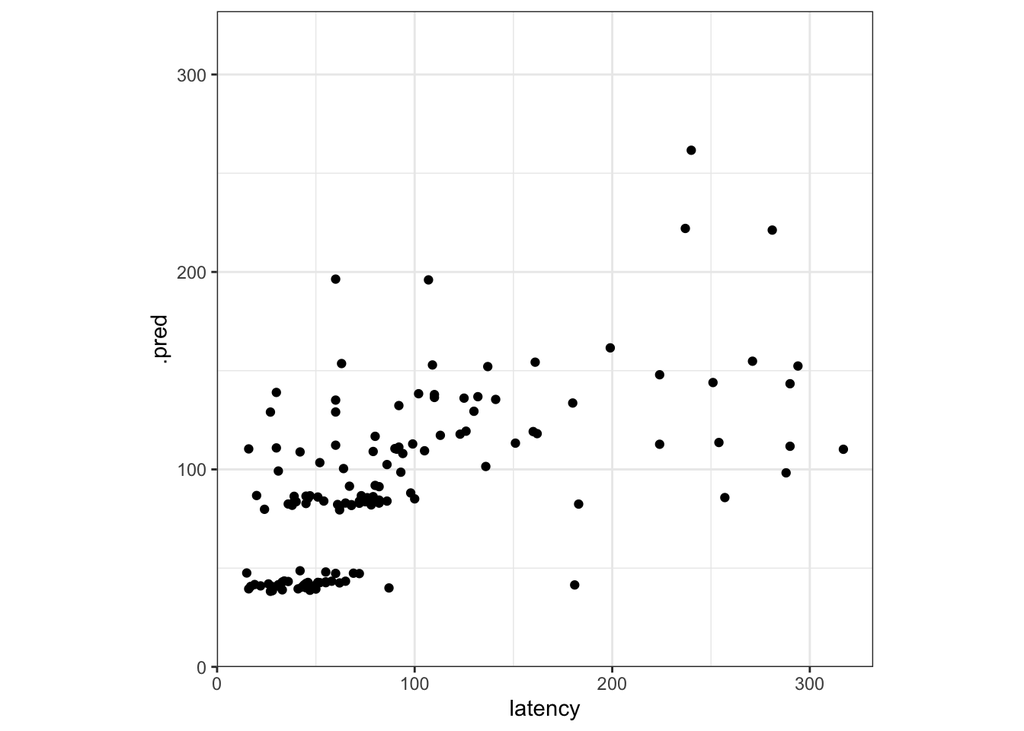

```r
ggplot(tree_frogs_test) +
  aes(x = latency,
      y = .pred) +
  geom_point() +
  coord_obs_pred()
```

```r
member_preds <-
  tree_frogs_test %>%
  select(latency) %>%
  bind_cols(predict(tree_frogs_model_st, tree_frogs_test, members = TRUE))
```

Now, evaluating the root mean squared error from each model:

```r
map_dfr(member_preds, rmse, truth = latency, data = member_preds) %>%
  mutate(member = colnames(member_preds))
```

```
## # A tibble: 6 × 4
##   .metric .estimator .estimate member
##   <chr>   <chr>          <dbl> <chr>
## 1 rmse    standard         0   latency
## 2 rmse    standard        55.3 .pred
## 3 rmse    standard       114.  knn_res_1_4
## 4 rmse    standard        55.5 lin_reg_res_1_1
## 5 rmse    standard       114.  svm_res_1_2
## 6 rmse    standard       114.  svm_res_1_6
```

As we can see, the stacked ensemble outperforms each of the member models, though is closely followed by one of its members.